# 01: proteinGroups.txt file analysis

# Libraries

```r
library(dplyr)
library(here)
library(DEP)
library(DT)
```

# Data input

Raw spectra were processed using the MaxQuant software, and the output, **proteinGroups.txt** file is used for further post-processing using the DEP R package.

```r
data <- read.delim(here('data', 'proteinGroups.txt'))
```

Prepare a folder for the outputs

```r
#dir.create(here('outputs', '01_DEP-processing'))
```

# Data preparation

## Contaminants filtering

```r
data <- data %>%
  filter(Reverse != "+") %>%
  filter(!grepl("cRAP", Majority.protein.IDs)) %>%
  filter(Only.identified.by.site != "+") %>%
  filter(!grepl("keratin", Fasta.headers)) %>%
  filter(!grepl("Keratin", Fasta.headers))
```

## Unique identifiers

```r
data_unique <- make_unique(data, "Gene.names", "Protein.IDs", delim = ";")
```

## BirA* binders filtering

To further filter out the proteins, which are unspecifically binding BirA* ligase, we took advantage of the CRAPOME resource within REPRINT.

For each BioID protocol employing BirA*-FLAG, a representative experiment (first in the order) was chosen. Altogether, 8 datasets were gathered and used for denoting BirA interactors.

A protein was considered to be BirA-sticky in case it was present in more than 5 experiments and had average spectra value > 20.

```r
# CRAPOME data input
BirA <- read.delim(here('data', '1669124109_userCrapDB.txt'))

BirA.sticky <- BirA %>%
    filter(NUM_EXPT > 5) %>%
    arrange(desc(AVE_SC)) %>%
    filter(AVE_SC > 20)

data.filtered <- data_unique %>%
  left_join(., BirA.sticky %>% select(GENE, AVE_SC, NUM_EXPT), by = c("name" = "GENE")) %>%
  filter(is.na(AVE_SC))
```

## Generate a SummarizedExperiment object

Create **experimental design** and filter out only the columns containing protein intensities.

```r
# Create experimental design
exp_design <- data.frame(
  label = c("1R.EE.01", "1R.EE.02", "1R.EE.03", "1R.EE.04", "1R.EE.05", "1R.EE.06", "1R.EE.07",
            "1R.EE.08", "1R.EE.09", "1R.EE.10", "1R.EE.11", "1R.EE.12",
            "2R.EE.01", "2R.EE.02", "2R.EE.03", "2R.EE.04", "2R.EE.05", "2R.EE.06", "2R.EE.07",
            "2R.EE.08", "2R.EE.09", "2R.EE.10", "2R.EE.11", "2R.EE.12",
            "3R.01", "3R.02", "3R.03", "3R.04", "3R.05", "3R.06", "3R.07", "3R.08", "3R.09",
            "3R.10", "3R.11", "3R.12"),
  condition = c("CTRL", "CTRL", "ROR1", "ROR1", "ROR2", "ROR2", "PRICKLE1", "PRICKLE1",
                "VANGL2", "VANGL2", "DVL3", "DVL3",
                "CTRL", "CTRL", "ROR1", "ROR1", "ROR2", "ROR2", "PRICKLE1", "PRICKLE1",
                "VANGL2", "VANGL2", "DVL3", "DVL3",
                "CTRL", "CTRL", "ROR1", "ROR1", "ROR2", "ROR2", "PRICKLE1", "PRICKLE1",
                "VANGL2", "VANGL2", "DVL3", "DVL3"),
  #  replicate = rep(c(1:3), each=12)
  replicate = c((rep(1:2, 6)), rep(3:4, 6), rep(5:6, 6) )
)

exp_design$label <- as.character(exp_design$label)
exp_design$condition <- as.character(exp_design$condition)
exp_design$replicate <- as.numeric(exp_design$replicate)

# find out which columns contain Intensities
intensity_columns <- grep("Intensity.", colnames(data_unique)) # get intensities column numbers
data_se <- make_se(data.filtered, intensity_columns, exp_design)
```

# Missing values filtering

Plot a barplot of the protein identification overlap between samples

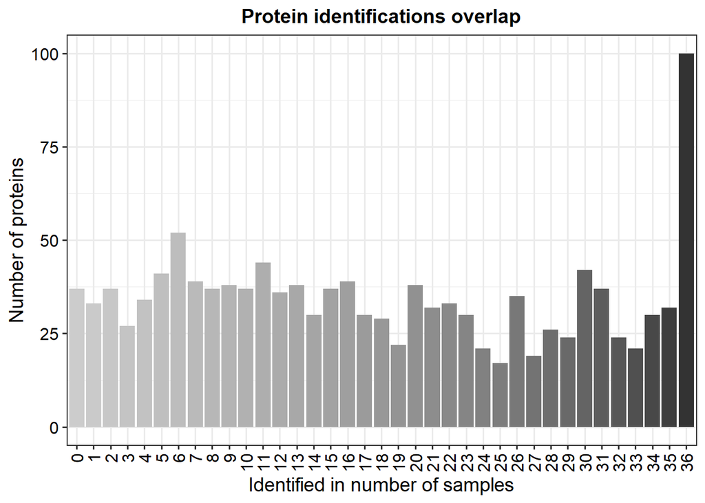

```r
plot_frequency(data_se)
```

Filter for proteins that are identified in **4/6 replicates** of at least **one** condition

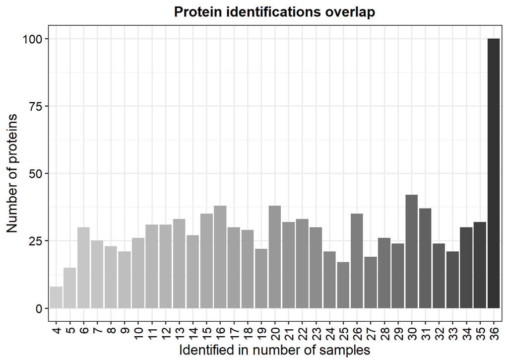

```r
data_filt <- filter_proteins(data_se, type = "condition",thr = 2)
plot_frequency(data_filt)
```

Plot a barplot of the number of identified proteins per samples

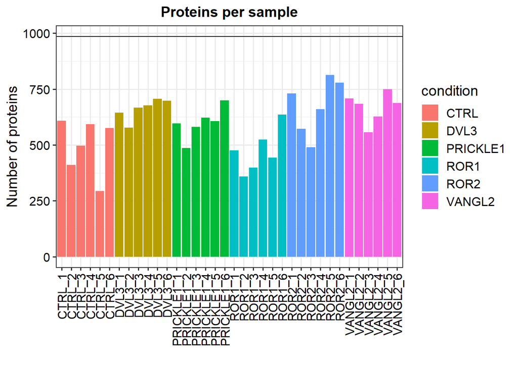

```r
plot_numbers(data_filt)
```

Plot a barplot of the protein identification overlap between samples

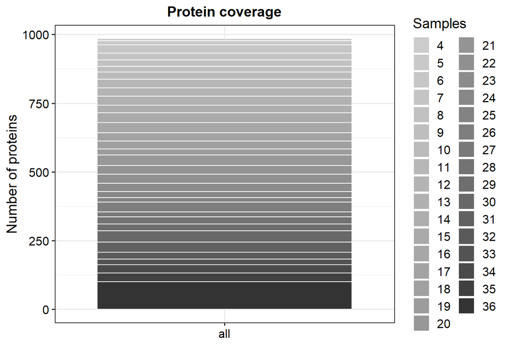

```r
plot_coverage(data_filt)
```

# Normalization

The data is background corrected and normalized by **variance stabilizing transformation (vsn)**

```r
# Normalize the data by vsn
data_norm_vsn <- normalize_vsn(data_filt)
```

## SD vs mean plots

Plot standard deviations vs mean plots

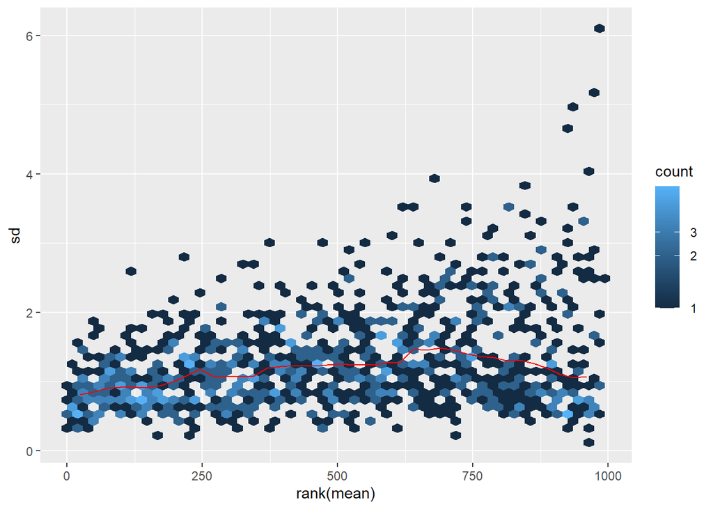

```r
meanSdPlot(data_norm_vsn)
```

## Boxplots

Visualize normalization by boxplots for all samples before and after normalization

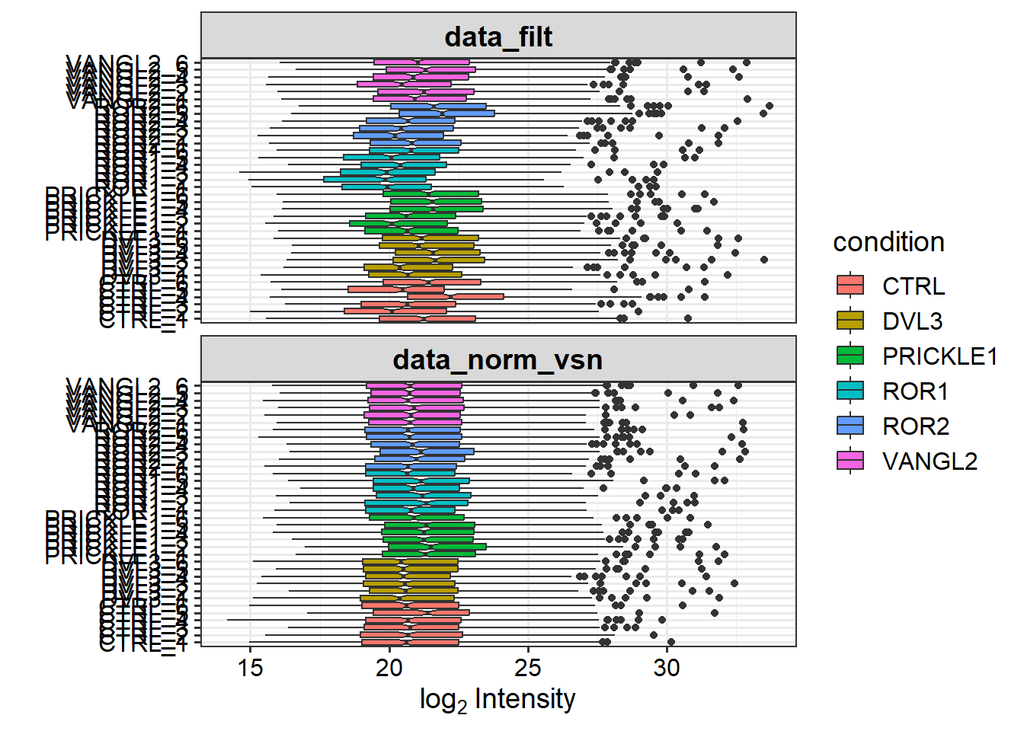

```r
plot_normalization(data_filt, data_norm_vsn)
```

# Missing values imputation

Plot a heatmap of proteins with missing values

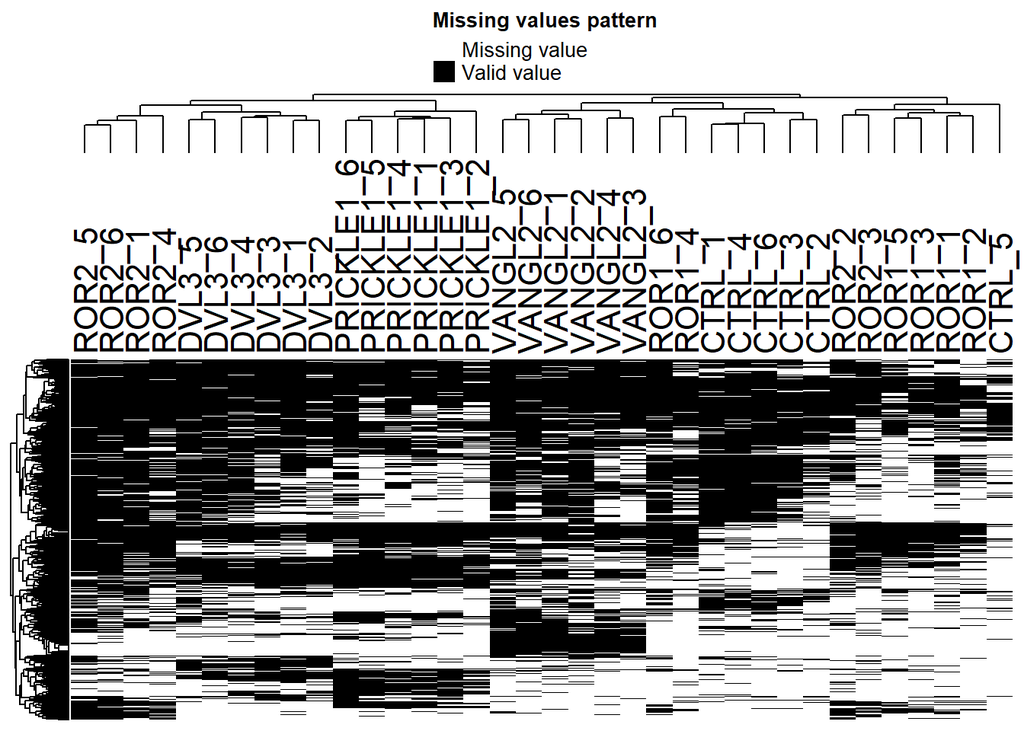

```r
plot_missval(data_filt)
```

Plot intensity distributions and cumulative fraction of proteins with and without missing values

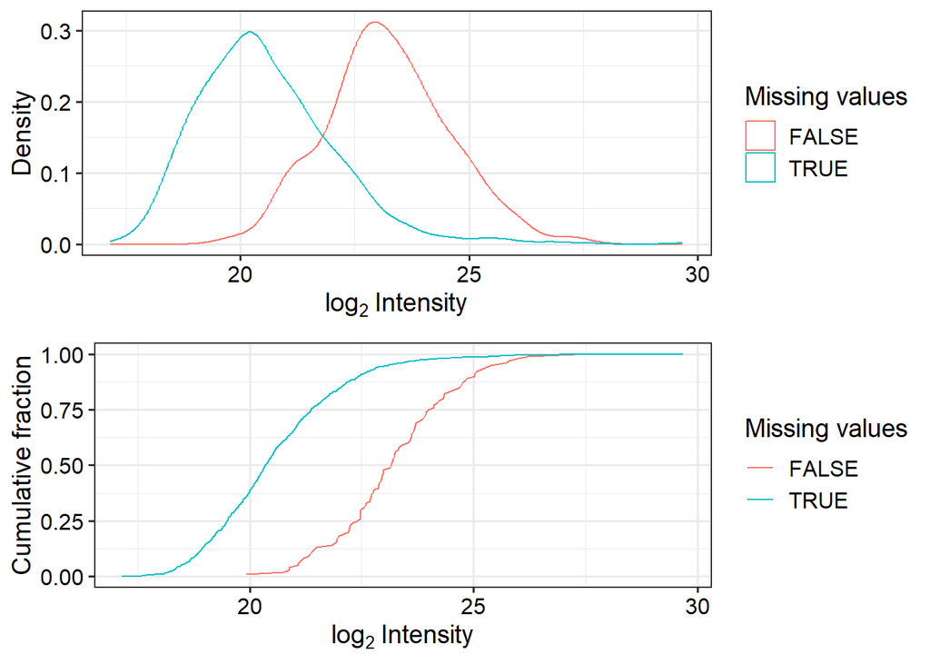

```r
plot_detect(data_filt)
```

Imputation of missing values:

Missing values of **MNAR** type, so **man** imputation used: impute missing data using random draws from a manually defined left-shifted Gaussian distribution

```r
# rather setting the seed; 42 is just purely the Hitchhiker's Guide to Galaxy reference :)
set.seed(42)
data_man <- impute(data_norm_vsn, fun = "man", shift = 1.8, scale = 0.3)
```

Plot intensity distributions before and after imputation.

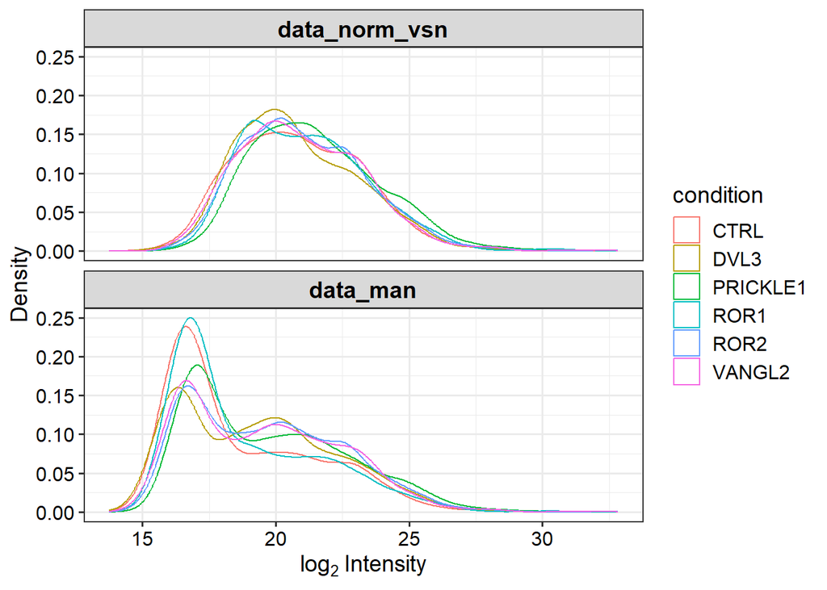

```r
plot_imputation(data_norm_vsn, data_man)
```

# Differential expression (LIMMA)

## LIMMA test

Adjustment of p-values done using **fdrtools** (by default)

```r
# Perform LIMMA test
data_diff_man <- test_diff(data_man, type = "manual",
                       test = c("DVL3_vs_CTRL",
                                "ROR1_vs_CTRL",
                                "ROR2_vs_CTRL",
                                "VANGL2_vs_CTRL",
                                "PRICKLE1_vs_CTRL"))

# Denote the significant proteins
dep_man <- add_rejections(data_diff_man, alpha = 0.05, lfc = log2(2))
```

## P-values histogram

For non-adjusted p-values

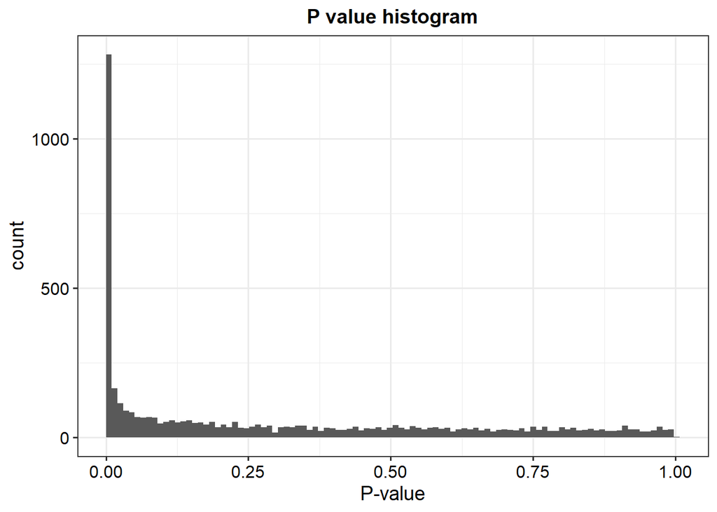

```r
plot_p_hist(dep_man, adjusted = FALSE) # plot pvalues histogram
```

## PCA

For 500 most variable proteins

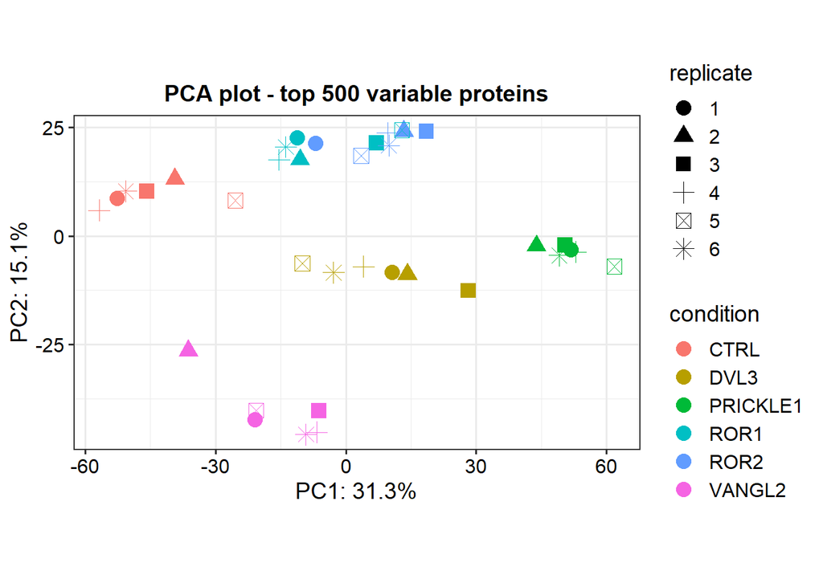

```r
plot_pca(dep_man, x = 1, y = 2, n = 500, point_size = 4) # plot PCA for 500 most variable proteins
```

## Correlation matrix

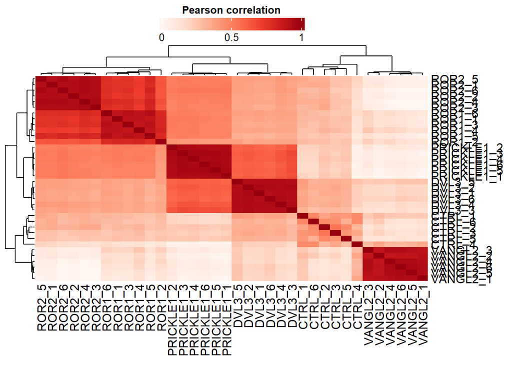

```r
plot_cor(dep_man, significant = TRUE, lower = 0, upper = 1, pal = "Reds") # plot correlation
```

## Heatmap (intensities)

```r
svg(here('outputs', '01_DEP-processing', '01_DEP_heatmap.svg'))
plot_heatmap(dep_man, type = "centered", kmeans = TRUE,
             k = 5, col_limit = 4, show_row_names = FALSE,
             indicate = c("condition", "replicate"))
graphics.off()

data.heatmap <- plot_heatmap(dep_man, type = "centered", kmeans = TRUE,
             k = 5, col_limit = 4, show_row_names = TRUE,
             indicate = c("condition", "replicate"), plot = FALSE)

cluster4 <- data.frame(cluster4 = data.heatmap$protein[data.heatmap$k == 4])
```

## Heatmap (contrasts)

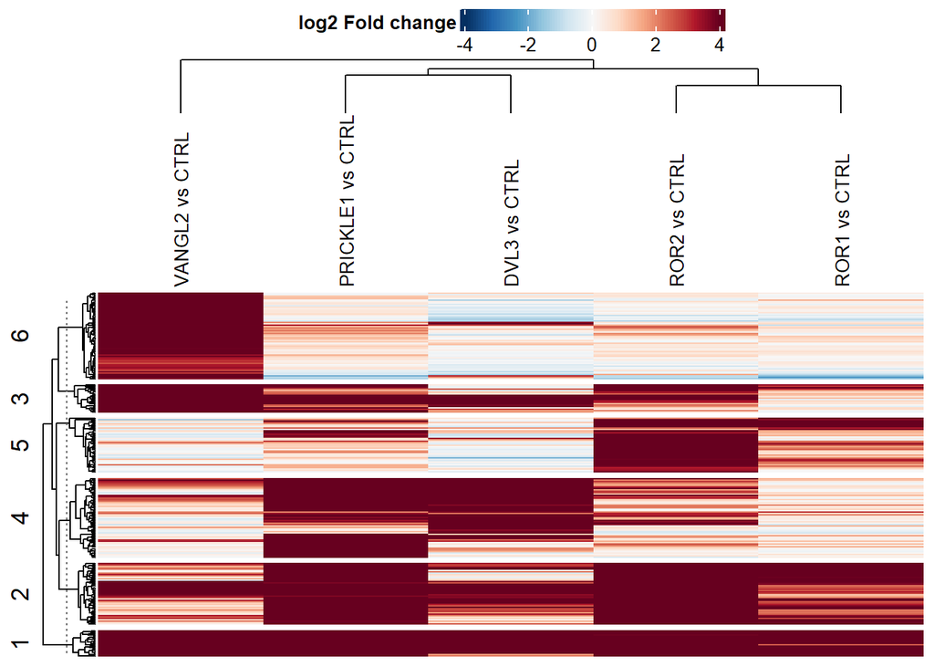

```r
plot_heatmap(dep_man, type = "contrast", kmeans = TRUE,
             k = 6, col_limit = 4, show_row_names = FALSE,
             indicate = c("condition", "replicate"))
```

## Adjusted pvalues (fdrtool)

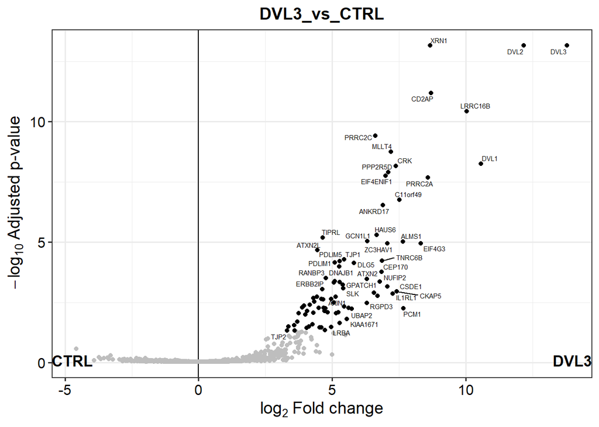

```r
plot_volcano(dep_man, contrast = "DVL3_vs_CTRL", label_size = 2, add_names = TRUE, adjusted = TRUE)
```

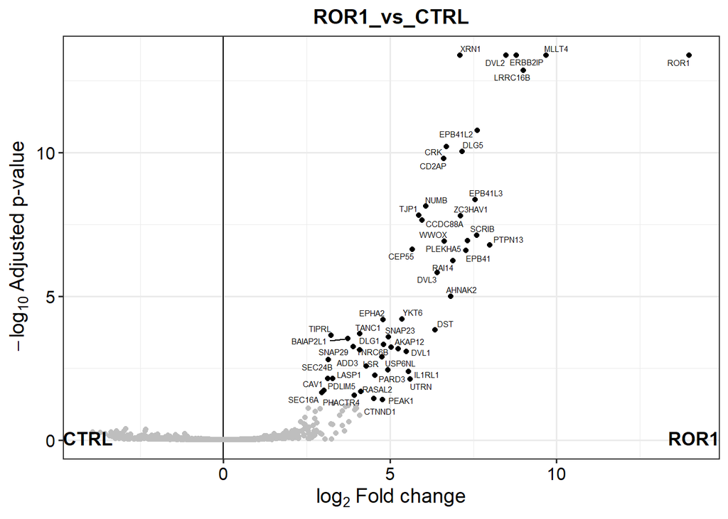

```r
plot_volcano(dep_man, contrast = "ROR1_vs_CTRL", label_size = 2, add_names = TRUE, adjusted = TRUE)
```

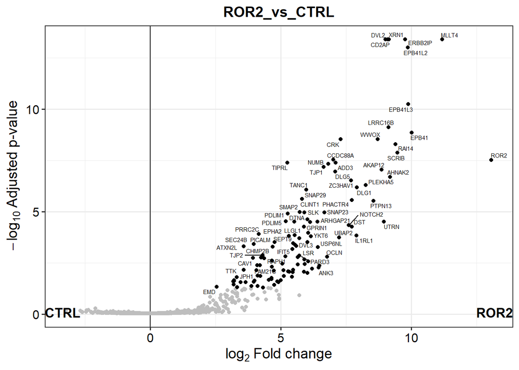

```r
plot_volcano(dep_man, contrast = "ROR2_vs_CTRL", label_size = 2, add_names = TRUE, adjusted = TRUE)
```

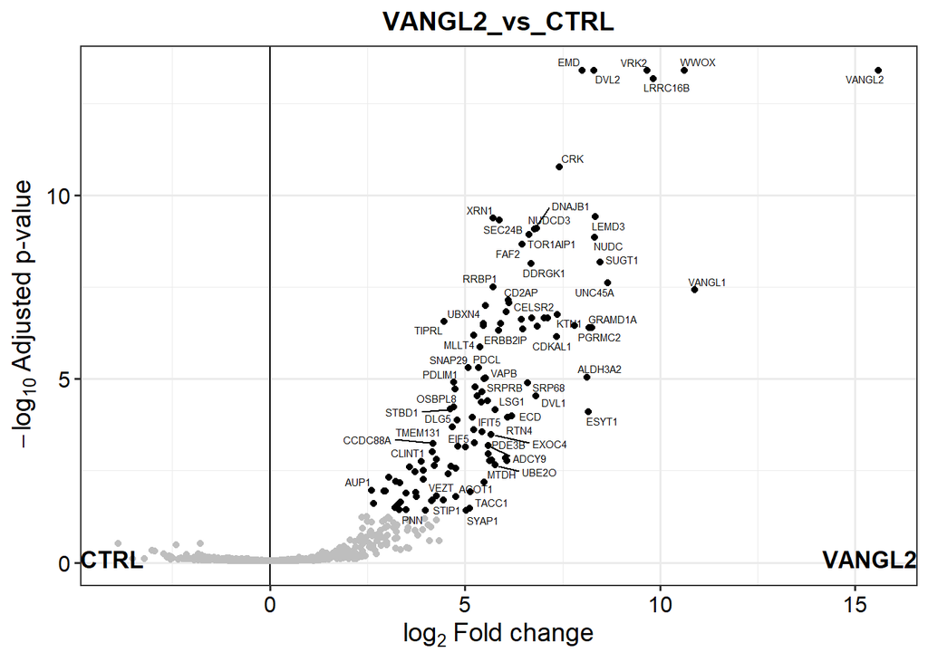

```r
plot_volcano(dep_man, contrast = "VANGL2_vs_CTRL", label_size = 2, add_names = TRUE, adjusted = TRUE)
```

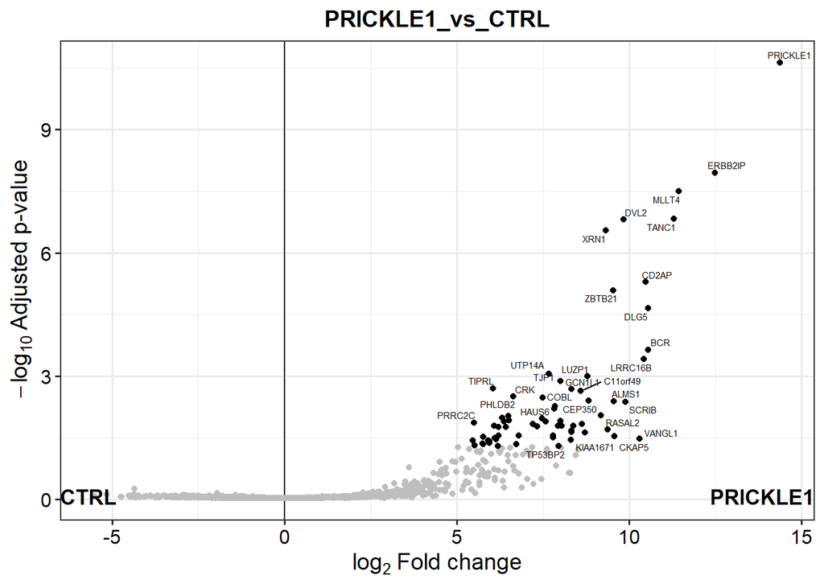

```r
plot_volcano(dep_man, contrast = "PRICKLE1_vs_CTRL", label_size = 2, add_names = TRUE, adjusted = TRUE)
```

# Summary tables

```r
# Generate a results table
data_results <- get_results(dep_man)
write.csv(data_results, here('outputs',  '01_DEP-processing', '01_DEP-results-table.csv'))

# Generate a wide data.frame
df_wide <- get_df_wide(dep_man)

# Generate a long data.frame
df_long <- get_df_long(dep_man)

# Save the data as RData
save(data_results, file = here('outputs',  '01_DEP-processing', '01_DEP-results-table.RData'))
save(df_wide, file = here('outputs',  '01_DEP-processing', '01_DEP-df-wide.RData'))
save(df_long, file = here('outputs',  '01_DEP-processing', '01_DEP-df-long.RData'))
save(dep_man, file = here('outputs',  '01_DEP-processing', '01_DEP-dep-object.RData'))
save(data.heatmap, file = here('outputs',  '01_DEP-processing', '01_DEP-heatmap-clusters.RData'))
```